# Analysis Summary level_1

Jian

26/01/2021

```r
# Load libraries
library(tidyverse)
library(plotly)
library(future)
library(furrr)
library(tidybulk)
library(cluster)
library(proxy)
library(factoextra)
library(stringr)
library(scales)
```

```r
# Load data
tt_L1 <- readRDS("intermediate_data/tt_L1.rds")
```

```r
# select level of interest
LEVEL = "level_1"

METHOD = "PCA"
```

```r
## 1 preprocess data

### 1.1 string manipulation that converts level of interest (e.g "level_5") to its ancestor level (e.g "level_4")
pre <- function(.level) {
  .level %>%
    str_split("_") %>%
    {as.numeric(.[[1]][2])-1} %>%
    paste("level", ., sep = "_")
}

### 1.2 preprocess

preprocess <- function(.data, .level) {

  # load data
  .data %>%

    tidybulk(sample, symbol, count) %>%

    # filter for the cell types of interest for gene marker selection
    filter(is.na(!!as.symbol(.level))==F) %>%

    # Imputation of missing data within each level_5
    # impute_missing_abundance(~ !!as.symbol(.level)) %>%

    # Group by ancestor
    nest(data = - !!as.symbol(pre(.level))) %>%

    # Eliminate genes that are present in some but all cell types
    # (can be still present in a subset of samples from each cell-type)
    mutate(data = map(
      data,
      ~ .x %>%
        nest(data = -c(symbol, !!as.symbol(.level))) %>%
        add_count(symbol) %>%
        filter(n == max(n)) %>%
        unnest(data)
    )) %>%

    # Imputation of missing data within each level_5
    mutate(data = map(data, ~ .x %>% impute_missing_abundance(~ !!as.symbol(.level)))) %>%

    # scale count for further analysis
    mutate(data=map(data, ~ .x %>%
                      identify_abundant(factor_of_interest = !!as.symbol(.level)) %>%
                      scale_abundance()
    ))
}

## 2 contrast functions

### 2.1 pairwise comparisons
get_contrasts_from_df = function(.data, .level){

  .data %>%
    distinct(!!as.symbol(.level)) %>%
    mutate(!!as.symbol(.level) := paste0(.level, !!as.symbol(.level))) %>%

    # Permute
    mutate(cell_type2 := !!as.symbol(.level)) %>%
    expand(!!as.symbol(.level), cell_type2) %>%
    filter(!!as.symbol(.level) != cell_type2) %>%

    # Create contrasts
    mutate(contrast = sprintf("%s - %s", !!as.symbol(.level), cell_type2)) %>%
    pull(contrast)

}

### 2.2 create a contrast vector for limma::makeContrasts() or tidybulk::test_differential abundance()

mean_contrast <- function(.data, .level){

  # find all cell types
  cell_types <- .data %>%
    distinct(!!as.symbol(.level)) %>%
    pull() %>%
    as.vector()

  # format cell_types with prefix
  cell_types <- paste0(.level, cell_types)

  # initialise a vector called contrasts
  contrasts <- 1: length(cell_types)

  # create all contrasts and store them in contrasts
  for(i in 1:length(cell_types) ){
    background = paste(cell_types[-i], collapse = "+")
    divisor = length(cell_types[-i])
    contrasts[i] <- sprintf("%s - (%s)/%s", cell_types[i], background, divisor)
  }

  return(contrasts)
}

## 3 marker ranking & selection

select_markers_for_each_contrast = function(.markers, .sig_size){
  .markers %>%

    # Group by contrast. Comparisons both ways.
    pivot_longer(
      cols = contains("___"),
      names_to = c("stats", "contrast"),
      values_to = ".value",
      names_sep="___"
    ) %>%

    # Markers selection within each pair of contrast
    nest(stat_df = -contrast) %>%

    # Reshape inside each contrast
    mutate(stat_df = map(stat_df, ~.x %>% pivot_wider(names_from = stats, values_from = .value))) %>%

    # Rank
    mutate(stat_df = map(stat_df, ~.x %>%
                           filter(FDR < 0.05 & logFC > 2) %>%
                           filter(logCPM > mean(logCPM)) %>%
                           arrange(logFC %>% desc()) %>%
                           slice(1: .sig_size)

    )) %>%

    unnest(stat_df)
}

## 4 marker collection for each contrast

### pairwise contrast method
contrast_PW <- function(.tt, .level){
  .tt %>%

    # Differential transcription gives all the statistics for each gene in each contrast
    mutate(markers = map(
      data,
      ~ test_differential_abundance(.x,
                                    ~ 0 + !!as.symbol(.level),
                                    .contrasts = get_contrasts_from_df(.x, .level),
                                    action="only")
    ))
}

### mean contrast method
contrast_MC <- function(.tt, .level){
  .tt %>%

    # Differential transcription
    mutate(markers = map(
      data,
      ~ test_differential_abundance(.x,
                                    ~ 0 + !!as.symbol(.level),
                                    .contrasts = mean_contrast(.x, .level),
                                    action="only")
    ))
}

### select signature genes and processing
sig_select <- function(.contrast, .level, .sig_size) {
  .contrast %>%

    # Select markers from each contrast by rank of stats
    mutate(markers = map(markers, ~ select_markers_for_each_contrast(.x, .sig_size))) %>%

    # Add original data info to the markers selected
    mutate(markers = map2(markers, data, ~ left_join(.x, .y))) %>%
    select(!!as.symbol(pre(.level)), markers) %>%
    unnest(markers) %>%

    # make contrasts pretty
    mutate(contrast_pretty = str_replace(contrast, .level, "") %>% str_replace(.level, ""))
}

# ====================================================================

single_marker_pw_select2 <- function(.contrast, .size, .level, .method) {

  # initialize variables
  signature <- vector()

  contrast_summary_tb <- tibble()

  contrast_copy <- .contrast

  # set the base markers
  contrast_pair_tb0 <-

    # contrast_copy contains all the statistics of all cell_type contrasts for each gene
    contrast_copy %>%

    # select top 1 markers from each contrast, output is an unnested tibble
    sig_select(.level, 1) %>%

    # enables markers from each contrast pair to be entitled to every other contrast so that
    # all the base genes rather than one base gene per contrast can be incorporated in each iteration
    nest(markers = - contrast_pretty) %>%

    expand(contrast_pretty, markers) %>%

    unnest(markers)

  # base markers
  base_markers <- contrast_pair_tb0 %>% pull(symbol) %>% unique()

  # remove base markers from contrast_copy input before further selection
  contrast_copy <- contrast_copy %>%
    mutate(markers = map(markers, ~.x %>%
                           filter(!symbol %in% base_markers) ))
```

```r
  # append the base markers
  signature <- append(signature, base_markers)

  while (length(signature) < .size) {

    contrast_pair_tb <-

      # contrast_PW_L1 contains all the statistics of all cell_type contrasts for each gene
      contrast_copy %>%

      # select top 1 markers from each contrast, output is an unnested tibble
      sig_select(.level, 1) %>%

      # combine markers at the base level before iteration
      bind_rows(contrast_pair_tb0) %>%

      # nest by pairwise contrast instead of ancestor level before
      nest(markers = - contrast_pretty) %>%

      # calculate silhouette score for PCA of cell types resolved by the selected 1 markers
      mutate(sil_pair = map(markers, ~ sil_func(.x, .level, .method))) %>%

      # make the silhouette score explicit
      mutate(sil_pair = map_dbl(sil_pair, ~ .x$sil)) %>%

      # rank silhouette score in a descending manner
      arrange(desc(sil_pair)) %>%

      # extract all the new markers from each contrast
      mutate(markers_new = map(markers, ~ .x %>% pull(symbol) %>% unique())) %>%

      # create a column of empty vectors to store cumulative markers below
      mutate(markers_cumu = map(contrast_pretty, ~ vector()) )

    # append the base + 1 markers that result in highest silhouette score
    signature <- signature %>% append(contrast_pair_tb$markers_new[[1]]) %>% unique()

    # store the selected contrast pair, markers and cumulative markers as a tibble
    contrast_summary_tb <- contrast_summary_tb %>%
      bind_rows(contrast_pair_tb[1, ] %>%
                  mutate(markers_cumu = map(markers_cumu, ~ .x %>% append(signature)))   )

    # remove the selected markers from contrast_PW_L1 so that other markers can be selected in later iterations
    contrast_copy <- contrast_copy %>%
      mutate(markers = map(markers, ~.x %>%
                             filter(!symbol %in% signature) ))
  }

  return(contrast_summary_tb)
}

single_marker_pw_select <- function(.contrast, .size, .level, .method) {

  # initialize variables
  signature <- vector()

  contrast_summary_tb <- tibble()

  contrast_copy <- .contrast

  # set the base markers
  contrast_pair_tb0 <-

    # contrast_copy contains all the statistics of all cell_type contrasts for each gene
    contrast_copy %>%

    # select top 1 markers from each contrast, output is an unnested tibble
    sig_select(.level, 1)

  # base markers
  base_markers <- contrast_pair_tb0 %>% pull(symbol) %>% unique()

  # remove base markers from contrast_copy input before further selection
  contrast_copy <- contrast_copy %>%
    mutate(markers = map(markers, ~.x %>%
                           filter(!symbol %in% base_markers) ))

  # append the base markers
  signature <- append(signature, base_markers)

  while (length(signature) < .size) {

    contrast_pair_tb <-

      # contrast_PW_L1 contains all the statistics of all cell_type contrasts for each gene
      contrast_copy %>%

      # select top 1 markers from each contrast, output is an unnested tibble
      sig_select(.level, 1) %>%

      # combine markers at the base level before iteration
      bind_rows(contrast_pair_tb0) %>%

      # nest by pairwise contrast instead of ancestor level before
      nest(markers = - contrast_pretty) %>%

      # calculate silhouette score for PCA of cell types resolved by the selected 1 markers
      mutate(sil_pair = map(markers, ~ sil_func(.x, .level, .method))) %>%

      # make the silhouette score explicit
      mutate(sil_pair = map_dbl(sil_pair, ~ .x$sil)) %>%

      # rank silhouette score in a descending manner
      arrange(desc(sil_pair)) %>%

      # extract all the new markers from each contrast
      mutate(markers_new = map(markers, ~ .x %>% pull(symbol) %>% unique())) %>%

      # create a column of empty vectors to store cumulative markers below
      mutate(markers_cumu = map(contrast_pretty, ~ vector()) )

    # append the base + 1 markers that result in highest silhouette score
    signature <- signature %>% append(contrast_pair_tb$markers_new[[1]]) %>% unique()

    # store the selected contrast pair, markers and cumulative markers as a tibble
    contrast_summary_tb <- contrast_summary_tb %>%
      bind_rows(contrast_pair_tb[1, ] %>%
                  mutate(markers_cumu = map(markers_cumu, ~ .x %>% append(signature)))   )

    # remove the selected markers from contrast_PW_L1 so that other markers can be selected in later iterations
    contrast_copy <- contrast_copy %>%
      mutate(markers = map(markers, ~.x %>%
                             filter(!symbol %in% signature) ))
  }

  return(contrast_summary_tb)
}

pair_marker_pw_select <- function(.contrast, .size, .level, .method) {

  # initialize variables
  signature <- vector()

  contrast_summary_tb <- tibble()

  contrast_copy <- .contrast

  while (length(signature) < .size) {

    contrast_pair_tb <-

      # contrast_PW_L1 contains all the statistics of all cell_type contrasts for each gene
      contrast_copy %>%

      # select top 1 markers from each contrast, output is an unnested tibble
      sig_select(.level, 2) %>%

      # nest by pairwise contrast instead of ancestor level before
      nest(markers = - contrast_pretty) %>%

      # calculate silhouette score for PCA of cell types resolved by the selected 1 markers
      mutate(sil_pair = map(markers, ~ sil_func(.x, .level, .method))) %>%

      # make the silhouette score explicit
      mutate(sil_pair = map_dbl(sil_pair, ~ .x$sil)) %>%

      # rank silhouette score in a descending manner
      arrange(desc(sil_pair)) %>%

      # extract all the new markers from each contrast
      mutate(markers_new = map(markers, ~ .x %>% pull(symbol) %>% unique())) %>%

      # create a column of empty vectors to store cumulative markers below
      mutate(markers_cumu = map(contrast_pretty, ~ vector()) )

    # append the base + 1 markers that result in highest silhouette score
    signature <- signature %>% append(contrast_pair_tb$markers_new[[1]]) %>% unique()
```

```r
    # store the selected contrast pair, markers and cumulative markers as a tibble
    contrast_summary_tb <- contrast_summary_tb %>%
      bind_rows(contrast_pair_tb[1, ] %>%
                  mutate(markers_cumu = map(markers_cumu, ~ .x %>% append(signature)))   )

    # remove the selected markers from contrast_PW_L1 so that other markers can be selected in later iterations
    contrast_copy <- contrast_copy %>%
      mutate(markers = map(markers, ~.x %>%
                             filter(!symbol %in% signature) ))
  }

  return(contrast_summary_tb)
}

sil_score_for_markers <-function(.contrast, .signature, .level, .method) {
  .contrast %>%
    # filter markers that are in the signature
    mutate(markers = map(markers, ~.x %>%
                           filter(symbol %in% .signature))) %>%

    # format statistics from pairwise contrast
    mutate(markers  = map(markers, ~ .x %>%
                            # Group by contrast. Comparisons both ways.
                            pivot_longer(
                              cols = contains("___"),
                              names_to = c("stats", "contrast"),
                              values_to = ".value",
                              names_sep="___"
                            ) %>%

                            # Markers selection within each pair of contrast
                            nest(stat_df = -contrast) %>%

                            # Reshape inside each contrast
                            mutate(stat_df = map(stat_df, ~.x %>%
                                                   pivot_wider(names_from = stats,
                                                               values_from = .value))) %>%

                            unnest(stat_df) )) %>%

    # Add original data info to the markers selected
    mutate(markers = map2(markers, data, ~ left_join(.x, .y))) %>%

    # select only columns needed
    select(!!as.symbol(pre(LEVEL)), markers) %>%
    unnest(markers) %>%

    # make contrasts pretty
    mutate(contrast_pretty = str_replace(contrast, LEVEL, "") %>% str_replace(LEVEL, "")) %>%

    # Calculate silhouette score for PCA plot resulted from the markers selected
    sil_func(.level, .method)
}

# =======================================================================
## 5
##5.1 calculate the area of confidence ellipses and the sum of their areas
ellipse <- function(.rdim, .level, .method) {
  .rdim %>%

    # remove non-numerical data to form a numerical data frame
    select(!!as.symbol(.level),
           contains(str_sub(.method, end=-2L))) %>%

    # normalize principle component values
    mutate(across(contains(str_sub(.method, end=-2L)), scale)) %>%

    # nest by cell_type so as to calculate ellipse area for each cell type
    nest(dims = - !!as.symbol(.level)) %>%

    # obtain covariance matrix for each cell type
    mutate(cov = map(dims, ~ cov(.x))) %>%

    # calculate the eigenvalues for the covariance matrix of each cell type
    mutate(eigval = map(cov, ~ eigen(.x)$values)) %>%

    # transformation
    mutate(area = map(eigval, ~ sqrt(.x * qchisq(0.95, 2)))) %>%

    # below is the actual area for each ellipse
    mutate(area = map_dbl(area, ~ prod(.x)*pi)) %>%

    # collect size of each cluster as factors for weights
    mutate(cluster_size = map_int(dims, ~ nrow(.x))) %>%

    # weight each area by the inverse of its cluster size
    mutate(weighted_area = map2_dbl(area, cluster_size, ~ .x / .y))
}

## 5.2 Ellipse area calculation
ellip_func <- function(.markers, .level, .method){
  .markers %>%

    # nest by ancestor cell types
    nest(rdim = - !!as.symbol(pre(.level))) %>%

    # reduce dimension
    mutate(rdim = map(rdim, ~ .x %>%
                        distinct(sample, symbol, count_scaled, !!as.symbol(.level)))) %>%
    mutate(rdim = map(rdim, ~ .x %>%
                        reduce_dimensions(sample, symbol, count_scaled,
                                          method = .method,
                                          action = "add",
                                          transform = log1p,
                                          # check_duplicates is for Rtsne method
                                          check_duplicates = FALSE) %>%

                        # save symbols for calculating real_size while reducing replicated rows resulted from symbol
                        nest(data_symbol = c(symbol, count_scaled))
    )) %>%

    mutate(real_size = map_int(rdim, ~ .x$data_symbol %>%
                                 map_int(~ n_distinct(.x$symbol)) %>%
                                 unlist() %>%
                                 unique() )) %>%

    mutate(area_df = map(rdim, ~ ellipse(.x, .level, .method) )
    )

}

## 5.3 Scale serialised ellip_func() output (a tibble called ellip_tb) for plotting
ellip_scale <- function(.ellip_tb, .level) {
  .ellip_tb %>%
    unnest(ellip) %>%
    unnest(area_df) %>%

    # nest by ancestor cell type to rescale area for all sig_sizes
    nest(cell_data = - !!as.symbol(pre(LEVEL))) %>%
    mutate(cell_data = map(cell_data, ~ .x %>%
                             mutate(rescaled_area = area %>%
                                      scale(center = F))
    )) %>%

    # nest by ancestor cell type to summarise areas for each real_size/sig_size
    mutate(plot_data = map(cell_data, ~ .x %>%
                             # sum all areas for each real_size for an ancestor node
                             group_by(real_size) %>%
                             summarise(sig_size,
                                       stded_sum=sum(area, na.rm = T),
                                       wted_sum = sum(weighted_area, na.rm = T),
                                       rescaled_sum= sum(rescaled_area, na.rm = T)) %>%
                             # remove duplicate rows
                             distinct(real_size, sig_size, stded_sum, wted_sum, rescaled_sum) %>%
                             pivot_longer(ends_with("sum"), names_to='area_type', values_to="area_value")
    ))
}
```

```r
## 6 Silhouette score calculation for a series of sig_sizes
sil_func <- function(.markers, .level, .method){
  .markers %>%
    nest(rdim = - !!as.symbol(pre(.level))) %>%
    mutate(rdim = map(rdim, ~ .x %>%
                        distinct(sample, symbol, count_scaled, !!as.symbol(.level)))) %>%
    mutate(rdim = map(rdim, ~ .x %>%
                        reduce_dimensions(sample, symbol, count_scaled,
                                          method = .method,
                                          action = "add",
                                          transform = log1p,
                                          # check_duplicates is for Rtsne method
                                          check_duplicates = FALSE) %>%

                        # save symbols for calculating real_size while reducing replicated rows resulted from symbol
                        nest(data_symbol = c(symbol, count_scaled))
    )) %>%

    # calculate the dissimilarity matrix with PC values
    mutate(distance = map(rdim, ~ .x %>%
                            select(contains(str_sub(.method, end = -2L))) %>%
                            factoextra::get_dist(method = "euclidean")
    )) %>%

    # calculate silhouette score
    mutate(sil = map2(rdim, distance,
                      ~ silhouette(as.numeric(as.factor(`$`(.x, !!as.symbol(.level)))), .y)
    )) %>%
    mutate(sil = map(sil, ~ .x %>% summary())) %>%
    mutate(sil = map(sil, ~ .x %>%
                       `$`(avg.width) ))%>%
    mutate(sil = unlist(sil)) %>%

    # obtain the actual number of signature genes
    mutate(real_size = map_int(rdim, ~ .x$data_symbol %>%
                                 map_int(~ n_distinct(.x$symbol)) %>%
                                 unlist() %>%
                                 unique() ))

}

# signature size optimation functions:
ratio <- function(.plot_data) {
  .plot_data %>%

    # too few markers won't be able to resolve cell types in a large mixed cohort hence remove them
    filter(real_size > 10) %>%

    # use min_max scaler to rescale real_size to the same scale as silhouette score (between 0 and 1)
    mutate(rs_rescaled = rescale(real_size, c(0, 1))) %>%

    # calculate the difference between rescaled size of the max sil point with that of all other points
    # the bigger different the better (even for negative numbers)
    mutate(diff_size = rs_rescaled[which.max(sil)] - rs_rescaled) %>%

    # calculate the difference between silhouette score of the max sil point and that of all other points
    # the smaller the better
    mutate(diff_sil = max(sil) - sil) %>%

    # calculate the ratio between diff_size/diff_sil, the bigger the better
    mutate(ratio = ifelse(diff_sil==0, diff_sil, diff_size / diff_sil))
}

optim_size <- function(.plot_data) {

  # if the highest silhouette score is the first point then select this point (no left points)
  if (which.max(.plot_data$sil) == 1) {
    op_size <- c(sig_size = .plot_data$sig_size[1],
                 real_size = .plot_data$real_size[1])

    # if the highest silhouette score is the last point then select the best left point (no right points)
  } else if (which.max(.plot_data$sil) == nrow(.plot_data)) {

    # find the index of the point that gives the best ratio to the left of max silhouette score point
    lop_index <- which.max(.plot_data$ratio[.plot_data$ratio > 0])

    op_size <- c(sig_size = .plot_data$sig_size[lop_index],
                 real_size = .plot_data$real_size[lop_index])

  } else {

    # find the index that gives the optimal point to the left of max silhouette score point
    lop_index <- which.max(.plot_data$ratio[.plot_data$ratio > 0])

    # find the index that gives the optimal point to the right of max silhouette score point
    rop_index <- which.max(.plot_data$sil) +
      which.max(.plot_data$ratio[.plot_data$ratio < 0])

    # choose the sizes of the optimal left point if its silhouette score is bigger than the optimal right point
    if (.plot_data$sil[lop_index] >= .plot_data$sil[rop_index]) {
      op_size <- c(sig_size = .plot_data$sig_size[lop_index],
                   real_size = .plot_data$real_size[lop_index])
    } else {
      # choose the max silhouette point if silhouette score of the optim right point is bigger than that of the left
      op_size <- c(sig_size = .plot_data$sig_size[which.max(.plot_data$sil)],
                   real_size = .plot_data$real_size[which.max(.plot_data$sil)])
    }
  }
  return(op_size)
}

penalized_sil <- function(.plot_data) {
  .plot_data %>%

    # too few markers won't be able to resolve cell types in a large mixed cohort hence remove them
    filter(real_size > 10) %>%

    # use min_max scaler to rescale real_size to the same scale as silhouette score (between 0 and 1)
    mutate(rs_rescaled = rescale(real_size, c(0, 1))) %>%

    mutate(penalized_sil = sil - 0.1 * rs_rescaled)
}

optim_size2 <- function(.plot_data) {
  index <- which.max(.plot_data$penalized_sil)
  op_size <- c(sig_size = .plot_data$sig_size[index],
               real_size = .plot_data$real_size[index])
  return(op_size)
}
```

# 1 Pre-analysis

## 1.1 Preprocess data

```r
# 1 Setup data frame & preprocessing

# tt_L1 <- counts %>%
#   # create an ancestor node for cell types on level_1
#   mutate(level_0 = "cell") %>%
#   preprocess(LEVEL)
```

```r
# View cell types on ancestor level_0
tt_L1 %>%
  unnest(data) %>%
  select(!!as.symbol(pre(LEVEL))) %>%
  distinct()
```

```
## # A tibble: 1 x 1
##   level_0
##   <chr>
## 1 cell
```

# 2 Hierarchy + Pairwise Analysis

## 2.0 Generate pairwise contrast

```r
contrast_PW_L1 <- tt_L1 %>%
  contrast_PW(LEVEL)
```

## 2.2 Silhouette Analysis

```r
sig_size <- 60

sil_tb_pw <-
  tibble(sig_size = 1:sig_size) %>%
  # slice(1) %>%
  mutate(sil_df = map(sig_size, ~ sig_select(contrast_PW_L1, LEVEL, .x))) %>%
  mutate(sil_df = map(sil_df, ~.x %>% sil_func(LEVEL, METHOD)))
```

### 2.2.1 Signature size optimisation with Naive Silhouette Score Approach

```r
sil_data_NSS <- sil_tb_pw %>%
  unnest(sil_df) %>%
  nest(plot_data = - !!as.symbol(pre(LEVEL)))
```

#### 2.2.1 NSS Signature size selection & PCA plot for cell

Signature size selection Trend Plot for cell:

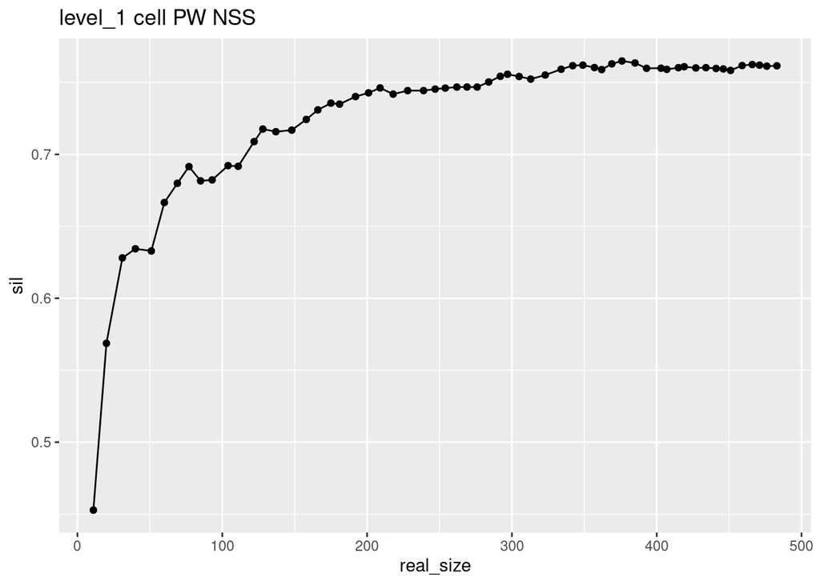

```r
cell_sil <- sil_data_NSS %>%
  # select ancestor cell type
  pluck("plot_data", 1) %>%
  ggplot(aes(real_size, sil)) +
  geom_line() +
  geom_point() +
  ggtitle("level_1 cell PW NSS")

cell_sil
```

Which sig_size gives maximum NSS:

```r
sil_data_NSS %>%
  pluck("plot_data", 1) %>%
  pull(sil) %>%
  which.max()
```

```
## [1] 44
```

What is the max silhouette score of NSS & real_size:

```r
sil_data_NSS %>%
  pluck("plot_data", 1) %>%
  slice(44)
```

```
## # A tibble: 1 x 5
##   sig_size rdim               distance             sil real_size
##      <int> <list>             <list>             <dbl>     <int>
## 1       44 <tibble [954 × 5]> <dist [954 × 954]> 0.765       376
```

The peak is reached when sig_size = $44$. PCA at sig_size = $44$:

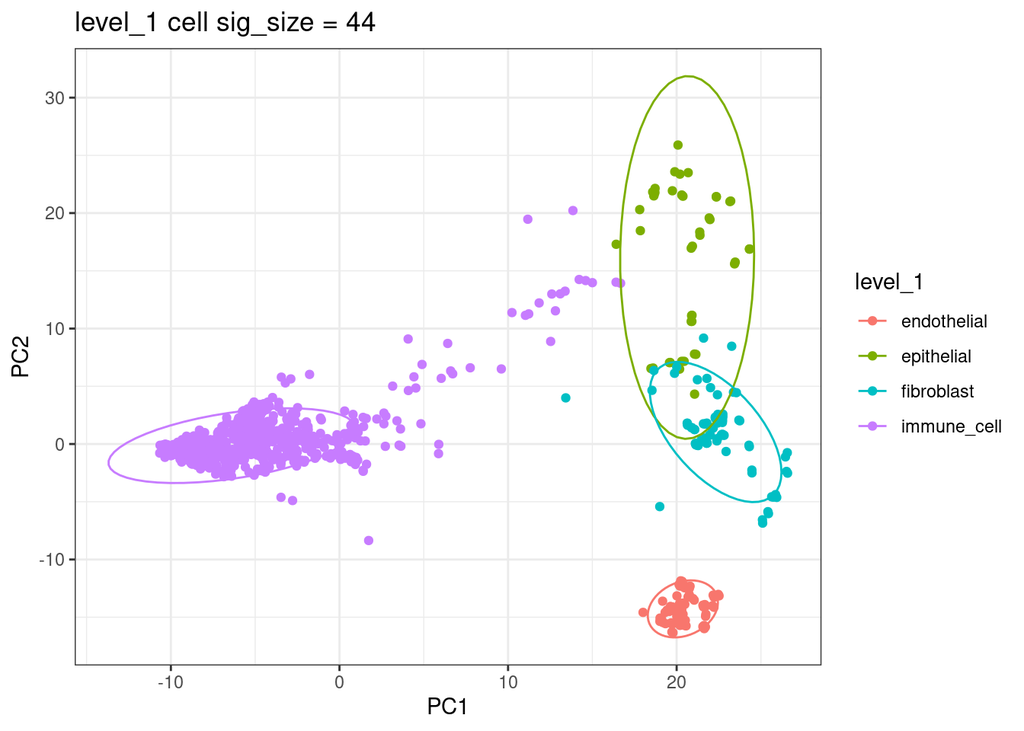

```r
# sig_size = 44

PCA1_cell_sil <- sil_data_NSS %>%
  # select ancestor cell type
  pluck("plot_data", 1) %>%
  # select data at optimal size
  pluck("rdim", 44) %>%
  ggplot(aes(x = PC1, y = PC2, colour = !!as.symbol(LEVEL), label = sample)) +
  geom_point() +
  stat_ellipse(type = 't')+
  theme_bw() +
  ggtitle("level_1 cell sig_size = 44")

PCA1_cell_sil
```

### 2.2.2 Signature size optimisation with Penalized Silhouette Score Approach

```r
sil_data_PSS <- sil_tb_pw %>%
  unnest(sil_df) %>%
  nest(plot_data = - !!as.symbol(pre(LEVEL))) %>%
  mutate(plot_data = map(plot_data, ~ .x %>% penalized_sil()) ) %>%
  mutate(optim_size = map(plot_data, ~ .x %>% optim_size2()))
```

#### 2.2.2 PSS Signature size selection & PCA plot for cell

Signature size selection Trend Plot for cell:

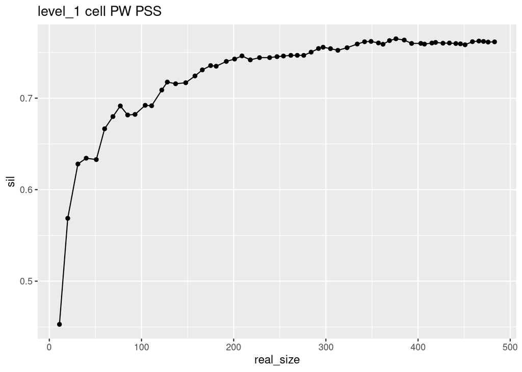

```r
cell_sil <- sil_data_PSS %>%
  pluck("plot_data", 1) %>%
  ggplot(aes(real_size, sil)) +
  geom_line() +
  geom_point() +
  ggtitle("level_1 cell PW PSS")

cell_sil
```

What is the optimal sig_size & real_size using PSS:

```r
sil_data_PSS %>% mutate(optim_size = map_df(optim_size, ~.x %>% unlist()))
```

```
## # A tibble: 1 x 3
##   level_0 plot_data         optim_size$sig_size $real_size
##   <chr>   <list>                          <int>      <int>
## 1 cell    <tibble [60 × 7]>                  23        209
```

What is the max silhouette score of PSS:

```r
sil_data_PSS %>%
  pluck("plot_data", 1) %>%
  pull(sil) %>%
  max()
```

```
## [1] 0.7648771
```

PCA at sig_size = $23$, real_size= $209$:

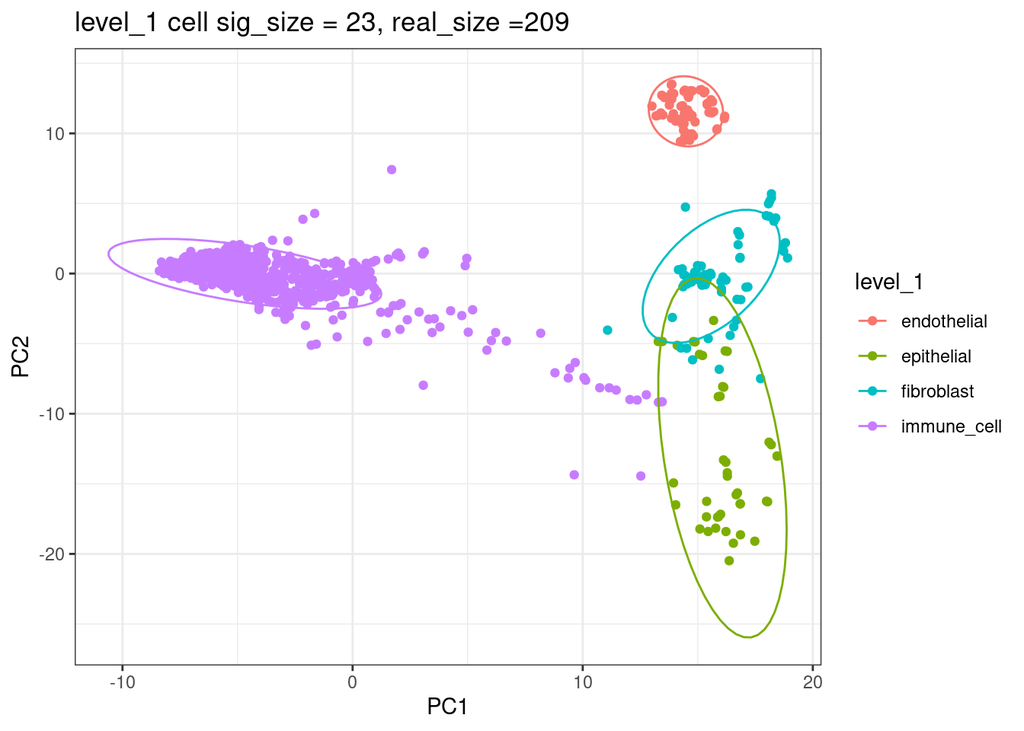

```r
# sig_size = 23, real_size = 209

PCA1_cell_sil <- sil_data_PSS %>%
  # select ancestor cell type
  pluck("plot_data", 1) %>%
  # select data at optimal size
  pluck("rdim", 23) %>%
  ggplot(aes(x = PC1, y = PC2, colour = !!as.symbol(LEVEL), label = sample)) +
  geom_point() +
  stat_ellipse(type = 't')+
  theme_bw() +
  ggtitle("level_1 cell sig_size = 23, real_size =209")

PCA1_cell_sil
```

### 2.2.3 Signature size optimisation with Distance Raito Approach

```r
sil_data_DR <- sil_tb_pw %>%
  unnest(sil_df) %>%
  nest(plot_data = - !!as.symbol(pre(LEVEL))) %>%
  mutate(plot_data = map(plot_data, ~ .x %>% ratio()) ) %>%
  mutate(optim_size = map(plot_data, ~ .x %>% optim_size()))
```

#### 2.2.3 DR Signature size selection & PCA plot for cell

Signature size selection Trend Plot for cell:

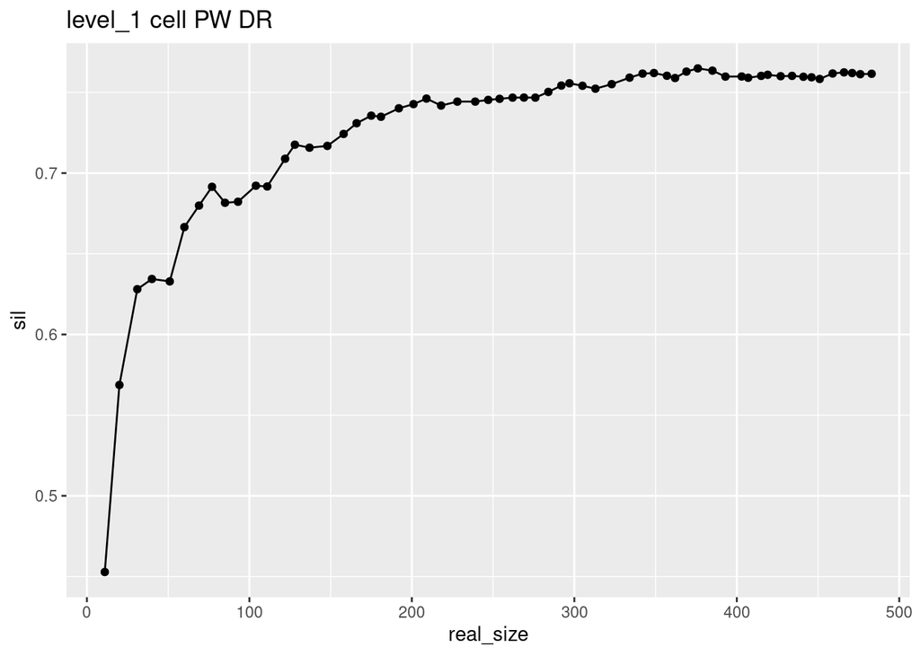

```r
cell_sil <- sil_data_DR %>%
  pluck("plot_data", 1) %>%
  ggplot(aes(real_size, sil)) +
  geom_line() +
  geom_point() +
  ggtitle("level_1 cell PW DR")

cell_sil
```

What is the optimal sig_size & real_size using DR:

```r
sil_data_DR %>% mutate(optim_size = map_df(optim_size, ~.x %>% unlist()))
```

```
## # A tibble: 1 x 3
##   level_0 plot_data         optim_size$sig_size $real_size
##   <chr>   <list>                          <int>      <int>
## 1 cell    <tibble [60 × 9]>                  39        342
```

What is the max silhouette score of DR:

```r
sil_data_DR %>%
  pluck("plot_data", 1) %>%
  pull(sil) %>%
  max()
```

```
## [1] 0.7648771
```

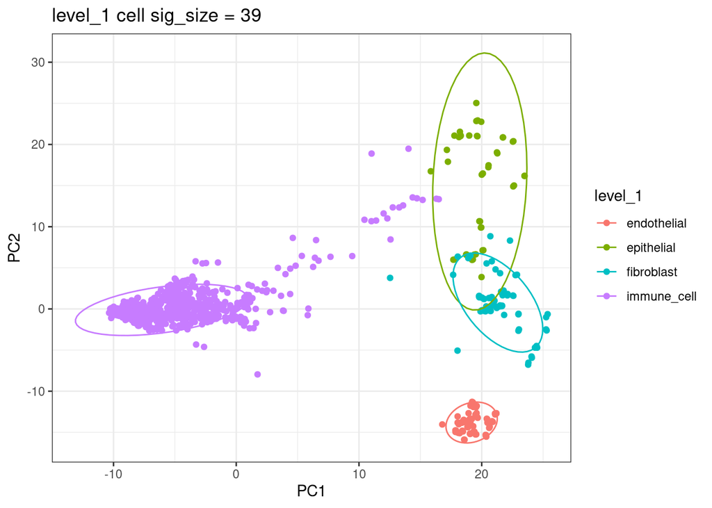

```r
PCA1_cell_sil <- sil_data_DR %>%
  # select ancestor cell type
  pluck("plot_data", 1) %>%
  # select data at optimal size
  pluck("rdim", 39) %>%
  ggplot(aes(x = PC1, y = PC2, colour = !!as.symbol(LEVEL), label = sample)) +
  geom_point() +
  stat_ellipse(type = 't')+
  theme_bw() +
  ggtitle("level_1 cell sig_size = 39")

PCA1_cell_sil
```

# 3 Hierarchy + mean contrast analysis

## 3.0 Generate mean contrast

```r
contrast_MC_L1 <- tt_L1 %>%
  contrast_MC(LEVEL)
```

## 3.2 Silhouette Analysis

```r
sig_size <- 60

sil_tb_mc <-
  tibble(sig_size = 1:sig_size) %>%
  # slice(1) %>%
  mutate(sil_df = map(sig_size, ~ sig_select(contrast_MC_L1, LEVEL, .x))) %>%
  mutate(sil_df = map(sil_df, ~.x %>% sil_func(LEVEL, METHOD)))
```

### 2.2.1 Signature size optimisation with Naive Silhouette Score Approach

```r
sil_data_NSS <- sil_tb_mc %>%
  unnest(sil_df) %>%
  nest(plot_data = - !!as.symbol(pre(LEVEL)))
```

#### 2.2.1 NSS Signature size selection & PCA plot for cell

Signature size selection Trend Plot for cell:

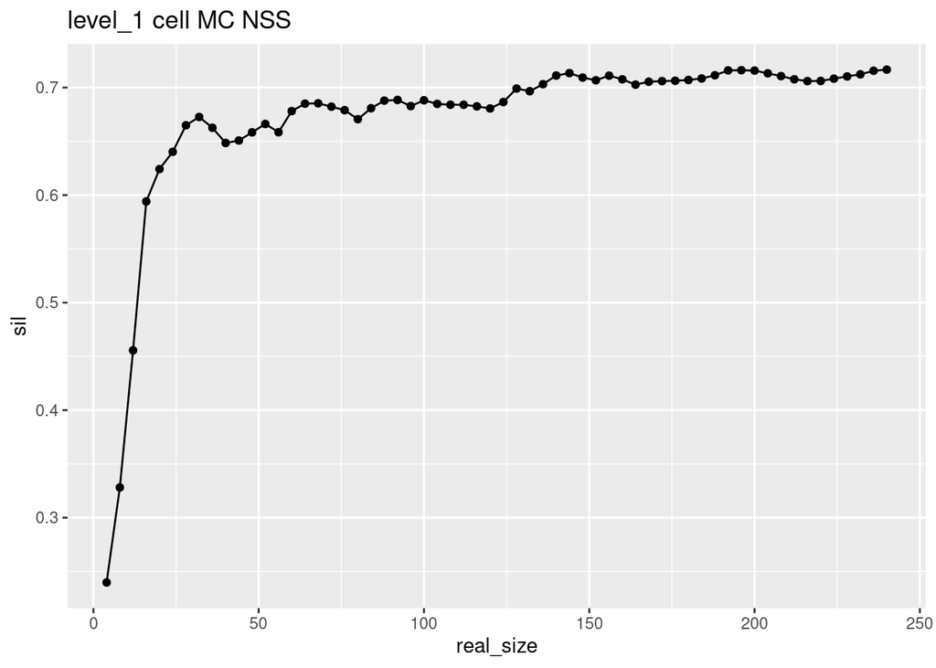

```r
cell_sil <- sil_data_NSS %>%
  # select ancestor cell type
  pluck("plot_data", 1) %>%
  ggplot(aes(real_size, sil)) +
  geom_line() +
  geom_point() +
  ggtitle("level_1 cell MC NSS")

cell_sil
```

Which sig_size gives maximum NSS:

```r
sil_data_NSS %>%
  pluck("plot_data", 1) %>%
  pull(sil) %>%
  which.max()
```

```
## [1] 60
```

What is the max silhouette score of NSS & real_size:

```r
sil_data_NSS %>%
  pluck("plot_data", 1) %>%
  slice(60)
```

```
## # A tibble: 1 x 5
##   sig_size rdim               distance             sil real_size
##      <int> <list>             <list>             <dbl>     <int>
## 1       60 <tibble [954 × 5]> <dist [954 × 954]> 0.717       240
```

The peak is reached when sig_size = $60$. PCA at sig_size = $60$:

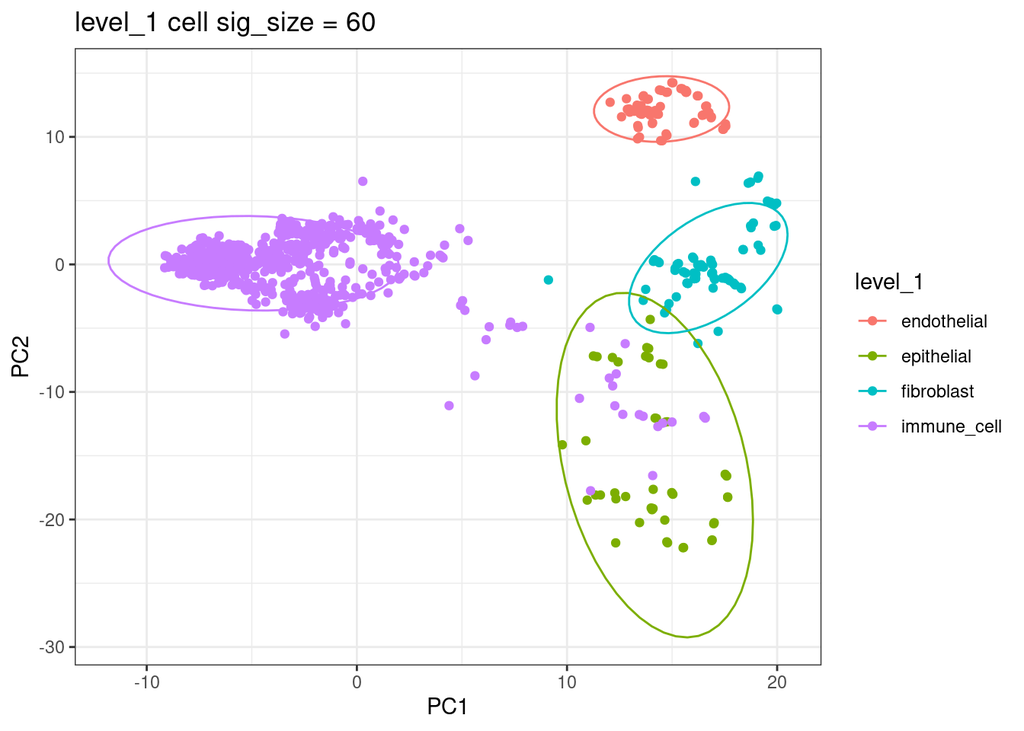

```r
# sig_size = 60

PCA1_cell_sil <- sil_data_NSS %>%
  # select ancestor cell type
  pluck("plot_data", 1) %>%
  # select data at optimal size
  pluck("rdim", 60) %>%
  ggplot(aes(x = PC1, y = PC2, colour = !!as.symbol(LEVEL), label = sample)) +
  geom_point() +
  stat_ellipse(type = 't')+
  theme_bw() +
  ggtitle("level_1 cell sig_size = 60")

PCA1_cell_sil
```

### 2.2.2 Signature size optimisation with Penalized Silhouette Score Approach

```r
sil_data_PSS <- sil_tb_mc %>%
  unnest(sil_df) %>%
  nest(plot_data = - !!as.symbol(pre(LEVEL))) %>%
  mutate(plot_data = map(plot_data, ~ .x %>% penalized_sil()) ) %>%
  mutate(optim_size = map(plot_data, ~ .x %>% optim_size2()))
```

#### 2.2.2 PSS Signature size selection & PCA plot for cell

Signature size selection Trend Plot for cell:

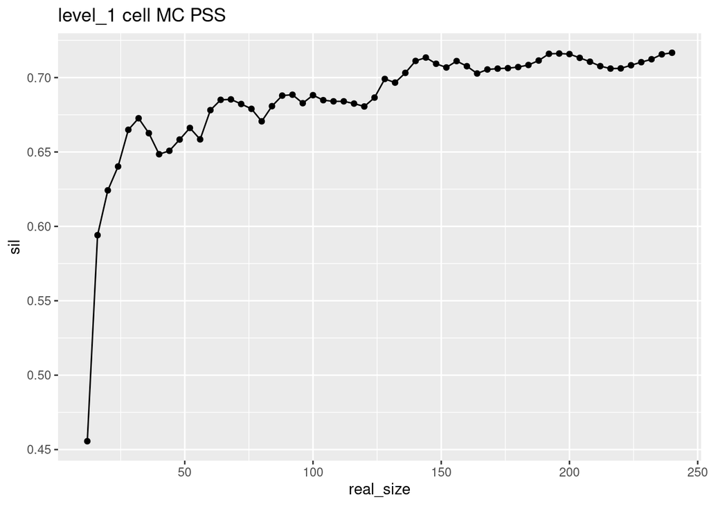

```r
cell_sil <- sil_data_PSS %>%
  pluck("plot_data", 1) %>%
  ggplot(aes(real_size, sil)) +
  geom_line() +
  geom_point() +
  ggtitle("level_1 cell MC PSS")

cell_sil
```

What is the optimal sig_size & real_size using PSS:

```r
sil_data_PSS %>% mutate(optim_size = map_df(optim_size, ~.x %>% unlist()))
```

```
## # A tibble: 1 x 3
##   level_0 plot_data         optim_size$sig_size $real_size
##   <chr>   <list>                          <int>      <int>
## 1 cell    <tibble [58 × 7]>                   8         32
```

What is the max silhouette score of PSS:

```r
sil_data_PSS %>%
  pluck("plot_data", 1) %>%
  pull(sil) %>%
  max()
```

```
## [1] 0.7166846
```

PCA at sig_size = $8$, real_size= $32$:

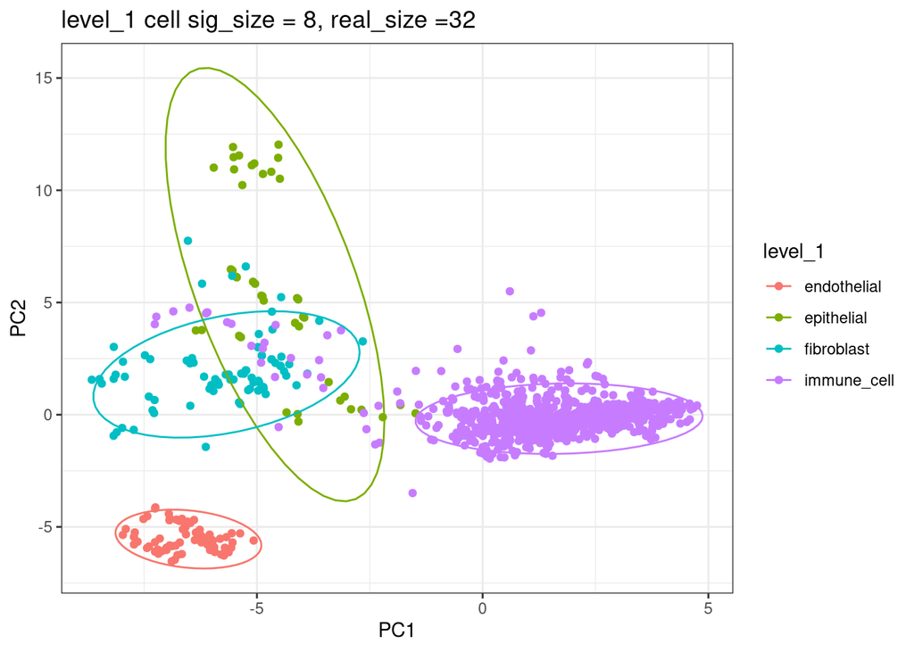

```r
# sig_size = 8, real_size = 32

PCA1_cell_sil <- sil_data_PSS %>%
  # select ancestor cell type
  pluck("plot_data", 1) %>%
  # select data at optimal size
  pluck("rdim", 8) %>%
  ggplot(aes(x = PC1, y = PC2, colour = !!as.symbol(LEVEL), label = sample)) +
  geom_point() +
  stat_ellipse(type = 't')+
  theme_bw() +
  ggtitle("level_1 cell sig_size = 8, real_size =32")

PCA1_cell_sil
```

### 2.2.3 Signature size optimisation with Distance Raito Approach

```r
sil_data_DR <- sil_tb_mc %>%
  unnest(sil_df) %>%
  nest(plot_data = - !!as.symbol(pre(LEVEL))) %>%
  mutate(plot_data = map(plot_data, ~ .x %>% ratio()) ) %>%
  mutate(optim_size = map(plot_data, ~ .x %>% optim_size()))
```

#### 2.2.3 DR Signature size selection & PCA plot for cell

Signature size selection Trend Plot for cell:

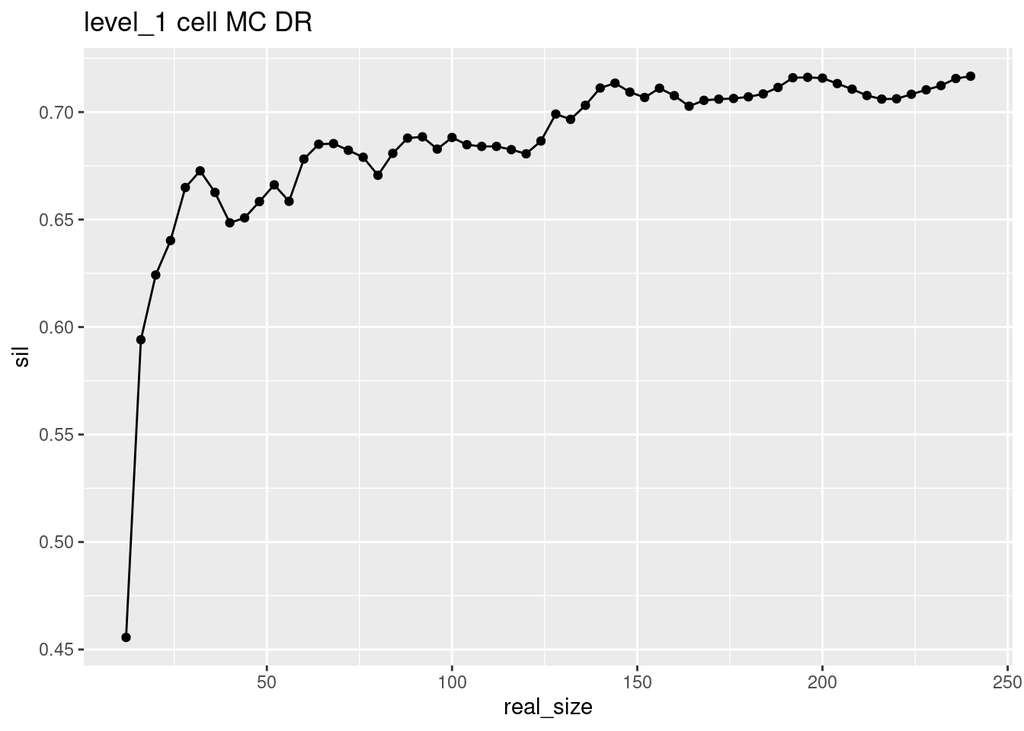

```r
cell_sil <- sil_data_DR %>%
  pluck("plot_data", 1) %>%
  ggplot(aes(real_size, sil)) +
  geom_line() +
  geom_point() +
  ggtitle("level_1 cell MC DR")

cell_sil
```

What is the optimal sig_size & real_size using DR:

```r
sil_data_DR %>% mutate(optim_size = map_df(optim_size, ~.x %>% unlist()))
```

```
## # A tibble: 1 x 3
##   level_0 plot_data         optim_size$sig_size $real_size
##   <chr>   <list>                          <int>      <int>
## 1 cell    <tibble [58 × 9]>                  49        196
```

What is the max silhouette score of DR:

```r
sil_data_DR %>%
  pluck("plot_data", 1) %>%
  pull(sil) %>%
  max()
```

```
## [1] 0.7166846
```

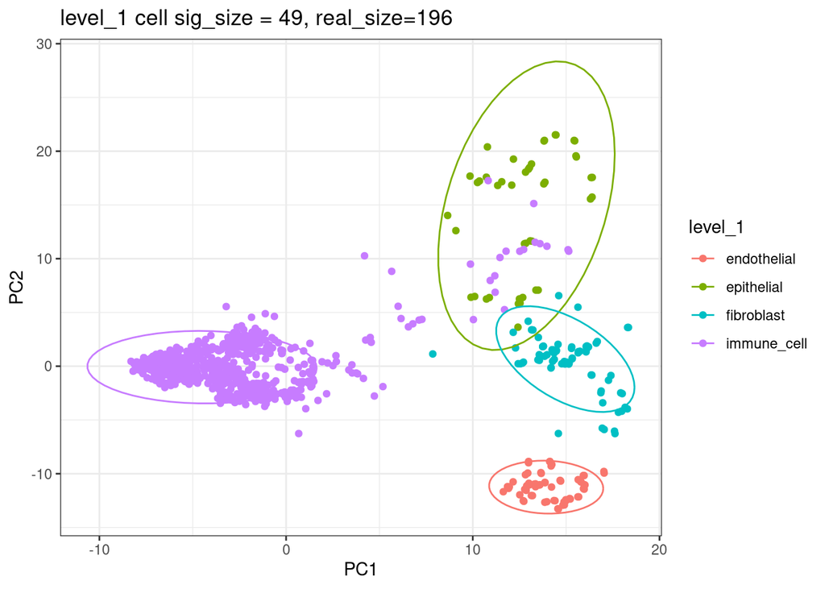

```r
PCA1_cell_sil <- sil_data_DR %>%
  # select ancestor cell type
  pluck("plot_data", 1) %>%
  # select data at optimal size
  pluck("rdim", 49) %>%
  ggplot(aes(x = PC1, y = PC2, colour = !!as.symbol(LEVEL), label = sample)) +
  geom_point() +
  stat_ellipse(type = 't')+
  theme_bw() +
  ggtitle("level_1 cell sig_size = 49, real_size=196")

PCA1_cell_sil
```